# Introduction

total försäljning, total marginal kr och %, Antal kunder, snittvärde per order, trend fsg och marginal.

Skapa ytterligare flikar där ni fokuserar på att analysera vilka produkter vi säljer samt en med fokus på vilka våra kunder är.

# Executive summary

## Libraries

```python
import glob
import pandas as pd
import matplotlib.pyplot as plt
%matplotlib inline
import seaborn as sns
```

## Import data

```python
# Load datasets
Categories = pd.read_excel('Categories.xlsx')
Customers = pd.read_excel('Customers.xlsx')
Divisions = pd.read_excel('Divisions.xlsx')
Orderdetails = pd.read_excel('Orderdetails.xlsx')
Orders = pd.read_excel('Orders.xlsx')
Products = pd.read_excel('Products.xlsx')
Shipments = pd.read_excel('Shipments.xlsx')
Shippers = pd.read_excel('Shippers.xlsx')
```

```python
# Save files to list
excelfiles = glob.glob('*.xlsx')

# Create an empty list: frames
frames = []
#  Iterate over files
for f in excelfiles:
    #  Read into a DataFrame
    dataframe = pd.read_excel(f)
    # Append df to frames
    frames.append(dataframe)
```

## First inspection

```python
excelfiles
```

```
['Products.xlsx',
 'Shippers.xlsx',
 'Customers.xlsx',
 'Divisions.xlsx',
 'Categories.xlsx',
 'Shipments.xlsx',
 'Orderdetails.xlsx',
 'Orders.xlsx']
```

```python
# see dimensions
for frame in frames:
    print(frame.shape)
```

```
(77, 9)
(3, 2)
(92, 11)
(4, 2)
(8, 3)
(17032, 7)
(17032, 6)
(6571, 6)
```

As evident from the printout above, the lowest three should be merged first. The other dataframes are merely lookup tables.

```python
# see columns
for frame in frames:
    print(frame.columns, "\n")
```

```
Index(['ProductID', 'ProductName', 'SupplierID', 'CategoryID',
       'QuantityPerUnit', 'UnitCost', 'UnitPrice', 'UnitsInStock',
       'UnitsOnOrder'],
      dtype='object')

Index(['ShipperID', 'CompanyName'], dtype='object')

Index(['CustomerID', 'CompanyName', 'ContactName', 'City', 'Country',
       'DivisionID', 'Address', 'Fax', 'Phone', 'PostalCode', 'StateProvince'],
      dtype='object')

Index(['DivisionID', 'DivisionName'], dtype='object')

Index(['CategoryID', 'CategoryName', 'Description'], dtype='object')

Index(['OrderID', 'LineNo', 'ShipperID', 'CustomerID', 'ProductID',
       'EmployeeID', 'ShipmentDate'],
      dtype='object')

Index(['OrderID', 'LineNo', 'ProductID', 'Quantity', 'UnitPrice', 'Discount'], dtype='object')

Index(['OrderID', 'OrderDate', 'CustomerID', 'EmployeeID', 'ShipperID',
       'Freight'],
      dtype='object')
```

# Merge datasets

We will merge all the datasets into one dataframe called df.

df should be in tidy data format, where one row = one item bought (i.e. OrderId & LineNo = df.ID)

Step 1: left join shipments and orders on CustomerID/EmployeeID and drop one col

Step 2: inner join shipments and orderdetails on OrderID/ProductID/EmployeeID and drop two cols

Step 3: replace the ID cols with the proper name:

- from ShipperID to CompanyName
- from ProductID to {all cols in that dataframe}.
- from CustomerID to CompanyName, City, Country. The other variables are dropped because the are not interesting (e.g. Phone nr is not important to analyze and StateProvince has high NA frequency.)
- from DivisionID to its name
- from CategoryID to its name

EmployeeID is kept as is. we can't know that because there is no lookup table but we keep it to avoid loss of information). Likewise, SupplierID is kept as is.

In summary, we merge Shipments, Orderdetails and Orders. Then we fill in the ID columns from the lookup tales. The result is a tidy dataset df where each row is a bought item.

qq göra hierakiskt index?

## Step 1: Shipments & Orders

https://stackoverflow.com/questions/21786490/pandas-left-outer-join-multiple-dataframes-on-multiple-columns

s1 = pd.merge(df1, df2, how='left', on=['Year', 'Week', 'Colour'])

```python
list(set(Shipments.columns) & set(Orders.columns))
```

```
['OrderID', 'ShipperID', 'EmployeeID', 'CustomerID']
```

```python
# SHipments and ORders
shor = pd.merge(Shipments, Orders, how='left',
                on=list(set(Shipments.columns) & set(Orders.columns)))
```

```python
assert Shipments.shape[0] == shor.shape[0]
```

```python
Shipments.shape, Orders.shape, shor.shape
```

```
((17032, 7), (6571, 6), (17032, 9))
```

## Step 2: shor & OrderDetails

```python
shor.shape, Orderdetails.shape
```

```
((17032, 9), (17032, 6))
```

```python
# SHipments and ORders and OrderDetails
shorod = pd.merge(shor, Orderdetails, how='left',
                  on=list(set(shor.columns) & set(Orderdetails.columns)))
```

```python
shorod_backup = shorod
```

```python
# check:
#print(Orderdetails.loc[Orderdetails.OrderID == 10248])
#shorod.head()
```

## Step 3: Replace some ID columns

```python
# rename cols
Customers.rename(columns={'CompanyName':'CustomerName'}, inplace=True)
Shippers.rename(columns={'CompanyName':'ShipperName'}, inplace=True)
```

### Shippers

```python
shorod.ShipperID.unique()
```

```
array([2, 1, 3, 4, 5])
```

```python
assert shorod.ShipperID.nunique() > Shippers.ShipperID.nunique()
```

This col will have NA since the lookup table 'Shipeprs' is incomplete. For that reason, we do not merge in Shippers but instead rename those IDs that have a name and the rest is kept as IDs.

```python
shorod['ShipperIDorName'] = shorod.ShipperID.replace(Shippers.ShipperName.to_dict())
```

### Products

```python
# assert we do not have the same problem as in Shippers
assert Products.ProductID.nunique() == shorod.ProductID.nunique()
```

```python
list(set(shorod.columns) & set(Products.columns))
```

```
['UnitPrice', 'ProductID']
```

```python
shorod = pd.merge(shorod, Products, how='left', on='ProductID')
```

```python
shorod.shape
```

```
(17032, 21)
```

```python
shorod.isnull().sum().sum()
```

```
0
```

```python
# almost all rows have different prices
(shorod.UnitPrice_x != shorod.UnitPrice_y).sum() / shorod.shape[0]
```

```
0.99917801784875526
```

```python
# from looking here it is not due to the discount
shorod.loc[shorod.Discount > 0, ['UnitPrice_x', 'UnitPrice_y', 'Discount']].head()
```

|  | UnitPrice_x | UnitPrice_y | Discount |
| --- | --- | --- | --- |
| 5 | 97.67 | 99.90 | 0.15 |
| 7 | 9.47 | 10.05 | 0.15 |
| 9 | 3.39 | 3.50 | 0.05 |
| 10 | 21.12 | 19.50 | 0.05 |
| 12 | 23.64 | 25.50 | 0.05 |

```python
# the discount does not explain it
97.67, 99.9*(1-0.15), 99.9-0.15
```

```
(97.67, 84.915, 99.75)
```

We do not know which price, the one from Orderdetails or from Products is the correct one. We suspect Orderdetails is more correct (up to date) so we choose that one.

```python
shorod.drop(['UnitPrice_y'], inplace=True, axis=1)
```

```python
shorod.rename(columns={'UnitPrice_x':'UnitPrice'}, inplace=True)
```

### Customers

```python
shorod = pd.merge(shorod, Customers[['CustomerID', 'CustomerName', 'City', 'Country', 'DivisionID']],
                  how='left', on='CustomerID')
```

```python
shorod.shape
```

```
(17032, 24)
```

### Divisions

```python
shorod = pd.merge(shorod, Divisions, how='left', on=list(set(shorod.columns) & set(Divisions.columns)))
```

```python
shorod.shape
```

```
(17032, 25)
```

```python
shorod = pd.merge(shorod, Categories, how='left', on=list(set(shorod.columns) & set(Categories.columns)))
```

```python
shorod.shape
```

```
(17032, 27)
```

```python
shorod.columns
```

```
Index(['OrderID', 'LineNo', 'ShipperID', 'CustomerID', 'ProductID',
       'EmployeeID', 'ShipmentDate', 'OrderDate', 'Freight', 'Quantity',
       'UnitPrice', 'Discount', 'ShipperIDorName', 'ProductName', 'SupplierID',
       'CategoryID', 'QuantityPerUnit', 'UnitCost', 'UnitsInStock',
       'UnitsOnOrder', 'CustomerName', 'City', 'Country', 'DivisionID',
       'DivisionName', 'CategoryName', 'Description'],
      dtype='object')
```

## Checkout df

```python
# rename to df
df = shorod
```

```python
# All ID variables can be dropped
# except EmployeeID and SupplierID and ShipperID
# because they do not have a lookup table
cols_ID = ['CustomerID', 'ProductID', 'CategoryID', 'DivisionID']
df.drop(cols_ID, inplace=True, axis=1)
```

```python
# CategoryName is suffient, the description of the category is not needed
df.drop(['Description'], inplace=True, axis=1)
```

```python
df.columns
```

```
Index(['OrderID', 'LineNo', 'ShipperID', 'EmployeeID', 'ShipmentDate',
       'OrderDate', 'Freight', 'Quantity', 'UnitPrice', 'Discount',
       'ShipperIDorName', 'ProductName', 'SupplierID', 'QuantityPerUnit',
       'UnitCost', 'UnitsInStock', 'UnitsOnOrder', 'CustomerName', 'City',
       'Country', 'DivisionName', 'CategoryName'],
      dtype='object')
```

```python
df.shape
```

```
(17032, 22)
```

```python
n = df.shape[0]
```

```python
# zero NA
assert df.isnull().sum().sum() == 0
```

```python
# first row
df.loc[0, :]
```

```
OrderID                            10248
LineNo                                 1
ShipperID                              2
EmployeeID                             2
ShipmentDate         2014-07-17 00:00:00
OrderDate            2014-06-29 00:00:00
Freight                            43.48
Quantity                              10
UnitPrice                          14.04
Discount                               0
ShipperIDorName    World Wide Transports
ProductName                Walking Shoes
SupplierID                            20
QuantityPerUnit                        1
UnitCost                           10.95
UnitsInStock                          26
UnitsOnOrder                           0
CustomerName            Dr Jims Trousers
City                              London
Country                               UK
DivisionName                      Europe
CategoryName            Women's Footwear
Name: 0, dtype: object
```

```python
df.describe()
```

|  | OrderID | LineNo | ShipperID | EmployeeID | Freight | Quantity | UnitPrice | Discount | SupplierID | QuantityPerUnit | UnitCost | UnitsInStock | UnitsOnOrder |
| --- | --- | --- | --- | --- | --- | --- | --- | --- | --- | --- | --- | --- | --- |
| count | 17032.000000 | 17032.000000 | 17032.000000 | 17032.000000 | 17032.000000 | 17032.000000 | 17032.000000 | 17032.000000 | 17032.000000 | 17032.000000 | 17032.000000 | 17032.000000 | 17032.000000 |
| mean | 13553.927078 | 2.107327 | 2.878112 | 4.950446 | 50.353610 | 24.936414 | 33.691178 | 0.055743 | 14.489373 | 23.679427 | 26.448995 | 39.760979 | 8.120597 |
| std | 1923.020984 | 1.550054 | 1.383721 | 2.865778 | 17.580939 | 20.186763 | 57.047959 | 0.083121 | 8.220952 | 28.540486 | 42.372797 | 36.060250 | 19.790074 |
| min | 10248.000000 | 1.000000 | 1.000000 | 1.000000 | 11.422512 | 1.000000 | 0.865024 | 0.000000 | 1.000000 | 1.000000 | 0.890000 | 0.000000 | 0.000000 |
| 25% | 11896.000000 | 1.000000 | 2.000000 | 3.000000 | 34.794019 | 11.000000 | 9.641237 | 0.000000 | 7.000000 | 1.000000 | 7.400000 | 17.000000 | 0.000000 |
| 50% | 13563.000000 | 2.000000 | 3.000000 | 5.000000 | 50.043621 | 20.000000 | 20.710736 | 0.000000 | 14.000000 | 15.000000 | 16.170000 | 25.000000 | 0.000000 |
| 75% | 15226.000000 | 3.000000 | 4.000000 | 8.000000 | 65.865146 | 33.000000 | 33.737649 | 0.100000 | 21.000000 | 26.000000 | 26.490000 | 57.000000 | 0.000000 |
| max | 16935.000000 | 25.000000 | 5.000000 | 9.000000 | 87.265707 | 168.000000 | 538.093967 | 0.250000 | 29.000000 | 105.000000 | 304.700000 | 125.000000 | 100.000000 |

```python
df.columns
```

```
Index(['OrderID', 'LineNo', 'ShipperID', 'EmployeeID', 'ShipmentDate',
       'OrderDate', 'Freight', 'Quantity', 'UnitPrice', 'Discount',
       'ShipperIDorName', 'ProductName', 'SupplierID', 'QuantityPerUnit',
       'UnitCost', 'UnitsInStock', 'UnitsOnOrder', 'CustomerName', 'City',
       'Country', 'DivisionName', 'CategoryName'],
      dtype='object')
```

```python
cols_1 = ['Freight', 'Quantity', 'UnitPrice', 'Discount',
          'ProductName', 'SupplierID', 'QuantityPerUnit',
          'UnitCost', 'UnitsInStock', 'UnitsOnOrder']
```

```python
cols_2 = ['OrderID', 'Freight', 'Quantity', 'UnitPrice', 'Discount',
          'ProductName', 'SupplierID', 'QuantityPerUnit',
          'UnitCost', 'UnitsInStock', 'UnitsOnOrder']
```

```python
set(df.columns) - set(cols_1)
```

```
{'CategoryName',
 'City',
 'Country',
 'CustomerName',
 'DivisionName',
 'EmployeeID',
 'LineNo',
 'OrderDate',
 'OrderID',
 'ShipmentDate',
 'ShipperID',
 'ShipperIDorName'}
```

```python
df.loc[df.QuantityPerUnit > 0, cols_1].head(10)
```

|  | Freight | Quantity | UnitPrice | Discount | ProductName | SupplierID | QuantityPerUnit | UnitCost | UnitsInStock | UnitsOnOrder |
| --- | --- | --- | --- | --- | --- | --- | --- | --- | --- | --- |
| 0 | 43.48 | 10 | 14.04 | 0.00 | Walking Shoes | 20 | 1 | 10.95 | 26 | 0 |
| 1 | 43.48 | 5 | 12.71 | 0.00 | Oyaki Kimono | 14 | 30 | 8.96 | 14 | 0 |
| 2 | 43.48 | 12 | 28.62 | 0.00 | Desperado Jeans | 5 | 25 | 21.10 | 22 | 30 |
| 3 | 29.20 | 9 | 22.80 | 0.00 | Kool Sunglasses | 6 | 21 | 20.36 | 35 | 0 |
| 4 | 29.20 | 40 | 101.20 | 0.00 | Summit Hiking Boots | 24 | 10 | 82.74 | 20 | 0 |
| 5 | 79.17 | 35 | 97.67 | 0.15 | Summit Hiking Boots | 24 | 10 | 82.74 | 20 | 0 |
| 6 | 79.17 | 10 | 9.59 | 0.00 | Duck Shirt | 19 | 1 | 7.28 | 85 | 0 |
| 7 | 79.17 | 15 | 9.47 | 0.15 | Stretch Pants | 2 | 40 | 8.68 | 76 | 0 |
| 8 | 43.41 | 20 | 9.26 | 0.00 | Stretch Pants | 2 | 40 | 8.68 | 76 | 0 |
| 9 | 43.41 | 6 | 3.39 | 0.05 | Ravellis Träskor | 9 | 90 | 2.65 | 104 | 0 |

```python
df[cols_2].head()
```

|  | OrderID | Freight | Quantity | UnitPrice | Discount | ProductName | SupplierID | QuantityPerUnit | UnitCost | UnitsInStock | UnitsOnOrder |
| --- | --- | --- | --- | --- | --- | --- | --- | --- | --- | --- | --- |
| 0 | 10248 | 43.48 | 10 | 14.04 | 0.0 | Walking Shoes | 20 | 1 | 10.95 | 26 | 0 |
| 1 | 10248 | 43.48 | 5 | 12.71 | 0.0 | Oyaki Kimono | 14 | 30 | 8.96 | 14 | 0 |
| 2 | 10248 | 43.48 | 12 | 28.62 | 0.0 | Desperado Jeans | 5 | 25 | 21.10 | 22 | 30 |
| 3 | 10249 | 29.20 | 9 | 22.80 | 0.0 | Kool Sunglasses | 6 | 21 | 20.36 | 35 | 0 |
| 4 | 10249 | 29.20 | 40 | 101.20 | 0.0 | Summit Hiking Boots | 24 | 10 | 82.74 | 20 | 0 |

```python
# create OrderPrice, i.e how much the customer pays for a particular product
df['PricePerQuantity'] = df.UnitPrice * df.QuantityPerUnit
df['OrderPrice'] = df['PricePerQuantity'] * df.Quantity  *(1-df.Discount)
```

```python
cols_3 = set(cols_1).union(set(['PricePerQuantity', 'OrderPrice']))
cols_3 = list(cols_3)
```

```python
df[cols_3].head()
```

|  | PricePerQuantity | Discount | UnitPrice | UnitsInStock | OrderPrice | Freight | SupplierID | UnitsOnOrder | QuantityPerUnit | ProductName | UnitCost | Quantity |
| --- | --- | --- | --- | --- | --- | --- | --- | --- | --- | --- | --- | --- |
| 0 | 14.04 | 0.0 | 14.04 | 26 | 140.4 | 43.48 | 20 | 0 | 1 | Walking Shoes | 10.95 | 10 |
| 1 | 381.30 | 0.0 | 12.71 | 14 | 1906.5 | 43.48 | 14 | 0 | 30 | Oyaki Kimono | 8.96 | 5 |
| 2 | 715.50 | 0.0 | 28.62 | 22 | 8586.0 | 43.48 | 5 | 30 | 25 | Desperado Jeans | 21.10 | 12 |
| 3 | 478.80 | 0.0 | 22.80 | 35 | 4309.2 | 29.20 | 6 | 0 | 21 | Kool Sunglasses | 20.36 | 9 |
| 4 | 1012.00 | 0.0 | 101.20 | 20 | 40480.0 | 29.20 | 24 | 0 | 10 | Summit Hiking Boots | 82.74 | 40 |

Example with purchasing socks: I buy 3 pair of socks and without any discounts it costs me £60 because:

- Quantity = 3
- Quantity/unit = 2 socks in a package
- Price/unit = Price for a sock = 10

Quantity = Q. Unit = U. Price = P.

Quantity is how much the customer buys, e.g. 3 in this example. UnitPrice = £10 for a sock. QuantityPerUnit is associated with the product, .

due to lacking variable description, we must unfortunately guess here. we are unsure but believe this is the correct variable interpretation

```python
# Assert every ProductName has the same QuantityPerUnit: all Desperado Jeans have 25
assert df.groupby('ProductName')['QuantityPerUnit'].std().sum() == 0
```

```python
# it does not hold for Quantity
assert df.groupby('ProductName')['Quantity'].std().sum() != 0
```

```python
# unprofitable rows
rows_loose_money = df.UnitPrice*(1-df.Discount) < df.UnitCost
print("Loose money on", rows_loose_money.mean(), "of purchases")
# PS. not OrderID so the entire order might be profitable
```

```
Loose money on 0.162752465946 of purchases
```

```python
# qq create variable ordervalue
# then see how many total order are unprofitable
dfo = df.groupby('OrderID')
```

```python
df.loc[df.UnitPrice < df.UnitCost, cols_1]
```

|  | Freight | Quantity | UnitPrice | Discount | ProductName | SupplierID | QuantityPerUnit | UnitCost | UnitsInStock | UnitsOnOrder |
| --- | --- | --- | --- | --- | --- | --- | --- | --- | --- | --- |
| 2167 | 44.500000 | 5 | 24.000000 | 0.04 | Lace Shoes | 29 | 30 | 25.39 | 17 | 0 |
| 2192 | 57.592226 | 17 | 8.220562 | 0.00 | Stretch Pants | 2 | 40 | 8.68 | 76 | 0 |
| 2193 | 57.592226 | 40 | 6.604405 | 0.00 | Baywatch Swimsuit | 16 | 12 | 6.76 | 111 | 0 |
| 2198 | 56.227689 | 23 | 100.648949 | 0.00 | Davenport Shoes | 12 | 1 | 100.74 | 0 | 0 |
| 2199 | 56.227689 | 21 | 33.686378 | 0.25 | Slip-on Shoes | 26 | 15 | 34.17 | 21 | 10 |
| 2227 | 76.355404 | 46 | 23.156712 | 0.00 | X-Train Shoes | 4 | 30 | 24.39 | 4 | 20 |
| 2259 | 68.348155 | 43 | 19.934790 | 0.25 | Kool Sunglasses | 6 | 21 | 20.36 | 35 | 0 |
| 2260 | 68.348155 | 32 | 7.351125 | 0.00 | Rossi Bermuda Shorts | 14 | 20 | 7.53 | 0 | 70 |
| 2275 | 47.860527 | 27 | 24.176422 | 0.00 | Atles Lussekofta | 15 | 10 | 26.49 | 26 | 0 |
| 2277 | 47.860527 | 13 | 10.497427 | 0.00 | Wrap Skirt | 12 | 1 | 10.95 | 32 | 0 |
| 2280 | 51.660425 | 33 | 5.087460 | 0.00 | LA. Shorts | 16 | 14 | 5.17 | 20 | 0 |
| 2311 | 60.093389 | 39 | 63.454481 | 0.20 | Okkaba Skin Jackets | 20 | 7 | 67.17 | 27 | 0 |
| 2321 | 23.540652 | 9 | 48.432668 | 0.00 | Jack Flash Dress | 24 | 6 | 52.38 | 0 | 0 |
| 2341 | 67.844771 | 2 | 25.698054 | 0.00 | Bike Helmet | 11 | 1 | 26.13 | 15 | 0 |
| 2347 | 21.683390 | 10 | 31.255615 | 0.25 | Feiss Fleece Trousers | 25 | 20 | 33.18 | 115 | 0 |
| 2399 | 36.522250 | 3 | 7.056990 | 0.10 | Rossi Bermuda Shorts | 14 | 20 | 7.53 | 0 | 70 |
| 2400 | 36.522250 | 16 | 65.501153 | 0.10 | Winter Boots | 24 | 14 | 70.81 | 38 | 0 |
| 2401 | 36.522250 | 22 | 3.592494 | 0.10 | Samba Soccer Socks | 10 | 100 | 3.90 | 20 | 0 |
| 2402 | 42.167350 | 2 | 25.292355 | 0.00 | Atles Lussekofta | 15 | 10 | 26.49 | 26 | 0 |
| 2479 | 37.632321 | 66 | 15.719626 | 0.15 | Langoste Shirt | 2 | 15 | 16.58 | 4 | 100 |
| 2523 | 21.730052 | 13 | 8.614750 | 0.10 | Stretch Pants | 2 | 40 | 8.68 | 76 | 0 |
| 2533 | 52.279762 | 6 | 15.583136 | 0.00 | Duck Trousers | 19 | 1 | 16.34 | 123 | 0 |
| 2625 | 42.576882 | 31 | 10.088349 | 0.00 | Summer Shorts | 20 | 1 | 10.48 | 17 | 10 |
| 2630 | 42.468753 | 14 | 19.083223 | 0.05 | Rossi Shorts | 2 | 15 | 19.34 | 53 | 0 |
| 2632 | 66.374556 | 10 | 16.063238 | 0.20 | Duck Trousers | 19 | 1 | 16.34 | 123 | 0 |
| 2643 | 38.138995 | 37 | 7.354914 | 0.00 | Rossi Bermuda Shorts | 14 | 20 | 7.53 | 0 | 70 |
| 2731 | 76.884777 | 4 | 5.645272 | 0.00 | Sapporoo Gloves | 4 | 20 | 6.20 | 31 | 0 |
| 2753 | 28.604313 | 23 | 66.521578 | 0.00 | Okkaba Skin Jackets | 20 | 7 | 67.17 | 27 | 0 |
| 2754 | 28.604313 | 22 | 7.149596 | 0.00 | Rossi Bermuda Shorts | 14 | 20 | 7.53 | 0 | 70 |
| 2756 | 32.672570 | 21 | 10.747871 | 0.00 | Wrap Skirt | 12 | 1 | 10.95 | 32 | 0 |
| ... | ... | ... | ... | ... | ... | ... | ... | ... | ... | ... |
| 16214 | 67.994009 | 19 | 6.043616 | 0.00 | Sapporoo Gloves | 4 | 20 | 6.20 | 31 | 0 |
| 16246 | 32.355087 | 19 | 22.322081 | 0.00 | Baby Dark Lounge Suit | 13 | 1 | 22.71 | 10 | 0 |
| 16252 | 66.126138 | 27 | 8.754943 | 0.00 | Basket Shoes | 8 | 1 | 8.78 | 3 | 40 |
| 16305 | 32.048349 | 23 | 13.214576 | 0.10 | Finnish Swimsuit | 23 | 1 | 13.57 | 65 | 0 |
| 16307 | 32.048349 | 34 | 20.772046 | 0.00 | Baby Dark Lounge Suit | 13 | 1 | 22.71 | 10 | 0 |
| 16311 | 56.007476 | 4 | 8.338732 | 0.00 | Danske Treshoe | 21 | 100 | 8.44 | 5 | 70 |
| 16332 | 49.446358 | 45 | 34.670307 | 0.00 | Tracksuit | 11 | 1 | 36.06 | 49 | 0 |
| 16363 | 66.046382 | 6 | 6.384805 | 0.20 | Bow tie | 12 | 1 | 6.61 | 125 | 0 |
| 16381 | 41.124458 | 1 | 7.455756 | 0.00 | Rossi Bermuda Shorts | 14 | 20 | 7.53 | 0 | 70 |
| 16389 | 30.417394 | 44 | 6.362277 | 0.20 | Bow tie | 12 | 1 | 6.61 | 125 | 0 |
| 16453 | 81.020061 | 19 | 5.166830 | 0.00 | LA. Shorts | 16 | 14 | 5.17 | 20 | 0 |
| 16477 | 73.460713 | 9 | 4.911266 | 0.00 | LA. Shorts | 16 | 14 | 5.17 | 20 | 0 |
| 16483 | 33.029507 | 18 | 64.491949 | 0.20 | Okkaba Skin Jackets | 20 | 7 | 67.17 | 27 | 0 |
| 16610 | 52.907996 | 9 | 3.734671 | 0.00 | Samba Soccer Socks | 10 | 100 | 3.90 | 20 | 0 |
| 16719 | 32.871103 | 2 | 50.255980 | 0.00 | Jack Flash Dress | 24 | 6 | 52.38 | 0 | 0 |
| 16747 | 27.267191 | 9 | 7.223768 | 0.00 | Rossi Bermuda Shorts | 14 | 20 | 7.53 | 0 | 70 |
| 16751 | 29.073337 | 46 | 6.456788 | 0.05 | Bow tie | 12 | 1 | 6.61 | 125 | 0 |
| 16774 | 75.674970 | 7 | 65.026445 | 0.05 | Winter Boots | 24 | 14 | 70.81 | 38 | 0 |
| 16787 | 34.846947 | 5 | 27.828627 | 0.00 | WFS Shoes | 12 | 1 | 29.25 | 22 | 80 |
| 16809 | 74.476645 | 94 | 3.837621 | 0.00 | Samba Soccer Socks | 10 | 100 | 3.90 | 20 | 0 |
| 16833 | 31.425111 | 52 | 6.406659 | 0.15 | Baywatch Swimsuit | 16 | 12 | 6.76 | 111 | 0 |
| 16846 | 44.843190 | 11 | 3.550895 | 0.00 | Samba Soccer Socks | 10 | 100 | 3.90 | 20 | 0 |
| 16850 | 72.347004 | 32 | 10.635393 | 0.00 | Wrap Skirt | 12 | 1 | 10.95 | 32 | 0 |
| 16851 | 72.347004 | 27 | 17.460198 | 0.25 | Rossi Shorts | 2 | 15 | 19.34 | 53 | 0 |
| 16852 | 72.347004 | 32 | 3.716393 | 0.25 | Samba Soccer Socks | 10 | 100 | 3.90 | 20 | 0 |
| 16879 | 29.256389 | 17 | 8.265503 | 0.00 | Danske Treshoe | 21 | 100 | 8.44 | 5 | 70 |
| 16896 | 54.502945 | 14 | 16.036149 | 0.25 | Mr2 Trousers | 1 | 10 | 16.17 | 17 | 40 |
| 16957 | 82.456638 | 12 | 3.539806 | 0.20 | Samba Soccer Socks | 10 | 100 | 3.90 | 20 | 0 |
| 16980 | 70.046791 | 4 | 4.414256 | 0.00 | Game Over T-Shirt | 28 | 53 | 4.44 | 19 | 0 |
| 17022 | 47.139516 | 5 | 22.000413 | 0.04 | Lace Shoes | 29 | 30 | 25.39 | 17 | 0 |

775 rows × 10 columns

```python
df.loc[df.QuantityPerUnit > 0].head(10)
```

|  | OrderID | LineNo | ShipperID | EmployeeID | ShipmentDate | OrderDate | Freight | Quantity | UnitPrice | Discount | ... | SupplierID | QuantityPerUnit | UnitCost | UnitsInStock | UnitsOnOrder | CustomerName | City | Country | DivisionName | CategoryName |
| --- | --- | --- | --- | --- | --- | --- | --- | --- | --- | --- | --- | --- | --- | --- | --- | --- | --- | --- | --- | --- | --- |
| 0 | 10248 | 1 | 2 | 2 | 2014-07-17 | 2014-06-29 | 43.48 | 10 | 14.04 | 0.00 | ... | 20 | 1 | 10.95 | 26 | 0 | Dr Jims Trousers | London | UK | Europe | Women's Footwear |
| 1 | 10248 | 2 | 2 | 2 | 2014-07-17 | 2014-06-29 | 43.48 | 5 | 12.71 | 0.00 | ... | 14 | 30 | 8.96 | 14 | 0 | Dr Jims Trousers | London | UK | Europe | Women's Clothes |
| 2 | 10248 | 3 | 2 | 2 | 2014-07-17 | 2014-06-29 | 43.48 | 12 | 28.62 | 0.00 | ... | 5 | 25 | 21.10 | 22 | 30 | Dr Jims Trousers | London | UK | Europe | Men's Clothes |
| 3 | 10249 | 1 | 2 | 7 | 2013-07-23 | 2013-06-29 | 29.20 | 9 | 22.80 | 0.00 | ... | 6 | 21 | 20.36 | 35 | 0 | Boombastic | Münster | Germany | Europe | Children's Clothes |
| 4 | 10249 | 2 | 2 | 7 | 2013-07-23 | 2013-06-29 | 29.20 | 40 | 101.20 | 0.00 | ... | 24 | 10 | 82.74 | 20 | 0 | Boombastic | Münster | Germany | Europe | Men's Footwear |
| 5 | 10250 | 1 | 2 | 2 | 2014-07-21 | 2014-07-03 | 79.17 | 35 | 97.67 | 0.15 | ... | 24 | 10 | 82.74 | 20 | 0 | El Carnevale | Rio de Janeiro | Brazil | South America | Men's Footwear |
| 6 | 10250 | 2 | 2 | 2 | 2014-07-21 | 2014-07-03 | 79.17 | 10 | 9.59 | 0.00 | ... | 19 | 1 | 7.28 | 85 | 0 | El Carnevale | Rio de Janeiro | Brazil | South America | Baby Clothes |
| 7 | 10250 | 3 | 2 | 2 | 2014-07-21 | 2014-07-03 | 79.17 | 15 | 9.47 | 0.15 | ... | 2 | 40 | 8.68 | 76 | 0 | El Carnevale | Rio de Janeiro | Brazil | South America | Women's Clothes |
| 8 | 10251 | 1 | 2 | 7 | 2013-12-24 | 2013-12-02 | 43.41 | 20 | 9.26 | 0.00 | ... | 2 | 40 | 8.68 | 76 | 0 | Eintrach GS | Berlin | Germany | Europe | Women's Clothes |
| 9 | 10251 | 2 | 2 | 7 | 2013-12-24 | 2013-12-02 | 43.41 | 6 | 3.39 | 0.05 | ... | 9 | 90 | 2.65 | 104 | 0 | Eintrach GS | Berlin | Germany | Europe | Women's Footwear |

10 rows × 22 columns

```python
# what is units in stock and units on order?
(df.UnitsInStock < df.UnitsOnOrder).sum() / n
```

```
0.15435650540159698
```

```python
df.head()
```

|  | OrderID | LineNo | ShipperID | EmployeeID | ShipmentDate | OrderDate | Freight | Quantity | UnitPrice | Discount | ... | SupplierID | QuantityPerUnit | UnitCost | UnitsInStock | UnitsOnOrder | CustomerName | City | Country | DivisionName | CategoryName |
| --- | --- | --- | --- | --- | --- | --- | --- | --- | --- | --- | --- | --- | --- | --- | --- | --- | --- | --- | --- | --- | --- |
| 0 | 10248 | 1 | 2 | 2 | 2014-07-17 | 2014-06-29 | 43.48 | 10 | 14.04 | 0.0 | ... | 20 | 1 | 10.95 | 26 | 0 | Dr Jims Trousers | London | UK | Europe | Women's Footwear |
| 1 | 10248 | 2 | 2 | 2 | 2014-07-17 | 2014-06-29 | 43.48 | 5 | 12.71 | 0.0 | ... | 14 | 30 | 8.96 | 14 | 0 | Dr Jims Trousers | London | UK | Europe | Women's Clothes |
| 2 | 10248 | 3 | 2 | 2 | 2014-07-17 | 2014-06-29 | 43.48 | 12 | 28.62 | 0.0 | ... | 5 | 25 | 21.10 | 22 | 30 | Dr Jims Trousers | London | UK | Europe | Men's Clothes |
| 3 | 10249 | 1 | 2 | 7 | 2013-07-23 | 2013-06-29 | 29.20 | 9 | 22.80 | 0.0 | ... | 6 | 21 | 20.36 | 35 | 0 | Boombastic | Münster | Germany | Europe | Children's Clothes |
| 4 | 10249 | 2 | 2 | 7 | 2013-07-23 | 2013-06-29 | 29.20 | 40 | 101.20 | 0.0 | ... | 24 | 10 | 82.74 | 20 | 0 | Boombastic | Münster | Germany | Europe | Men's Footwear |

5 rows × 22 columns

## EDA: Make a nice summary table or graph

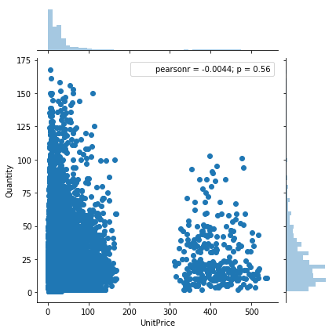

```python
sns.jointplot(x="UnitPrice", y="Quantity", data=df)
```